# hp2

Author

Jesse LeBow

# Homework Project 2

## The data

The data in this report comes from Hartshorne, Tenenbaum, & Pinker (2018) - A Critical Period for Second Language Acquisition: Evidence from 2/3 Million English Speakers.

Nearly 700,000 L1 and non-L1 English speakers took part in this massive study, which used a sizable grammaticality judgment assessment and a multifaceted demographic survey to allow for the establishment of multiple correlations to L2 English learning success.

I will be doing my own analysis of the data, with several questions in mind:

```r
library(tidyverse)
library(here)
library(knitr)
library(stringr)
library(tidyr)
```

## Importing Data

```r
#unzip the csv file (too large to upload to GitHub directly)
here::i_am("analysis/hp2-lebow.qmd")
```

```
here() starts at C:/Users/jesse/Documents/GitHub/hp2-jesselebow
```

```r
zip_file_path <- here::here("data/EnglishL2Acquisition.zip")
unzip(zip_file_path, exdir = here::here("data"))
df_eng_acquisition <- read.csv(here("data/EnglishL2Acquisition.csv"),
              skip = 0, sep = ",", comment.char = "#", strip.white = TRUE, col.names = c("id", "date", "time", "gender", "age", "L1s", "curr_langs", "dyslexia", "psychiatric", "education", "eng_start", "eng_count", "home_eng", "dictionary", "countries", "curr_country", "US_region", "UK_region", "CAN_region", "IR_region", "L1_eng", "curr_eng", "lived_eng_pct", "speaker_category", "correct"))
```

## Data Dictionary

Age: The age of the participant at the time of the trial L1s: Participant’s L1s Curr_langs: Participant’s currently spoken languages Dyslexia: Whether or not the participant reported having dyslexia Psychiatric: Whether or not the participant reported any psychiatric disorders Eng_start: What age the participant started learning English Eng_count: The number of years the participant has lived in an English-speaking country Home_eng: Whether the participant lives with any native English speakers L1_eng: Whether the participant is an L1 English speaker Correct: Total percentage of correct responses to questions

## Reformatting and handling missing values

Not too much to clean here. Just for readability, let’s multiply values in Correct by 100 so they’re actual percentages.

```r
df_eng_acquisition <- df_eng_acquisition |>
  mutate(correct = correct * 100)
```

There are a lot of NA and NULL values throughout the data, but there’s nothing really to be done about them. Luckily, there’s so much data that we can afford to just filter these rows out when we analyze.

## Exploring Question 1: (Predicted) Decline in L2 learning ability

We begin by plotting the average scores of all participants as a function of age.

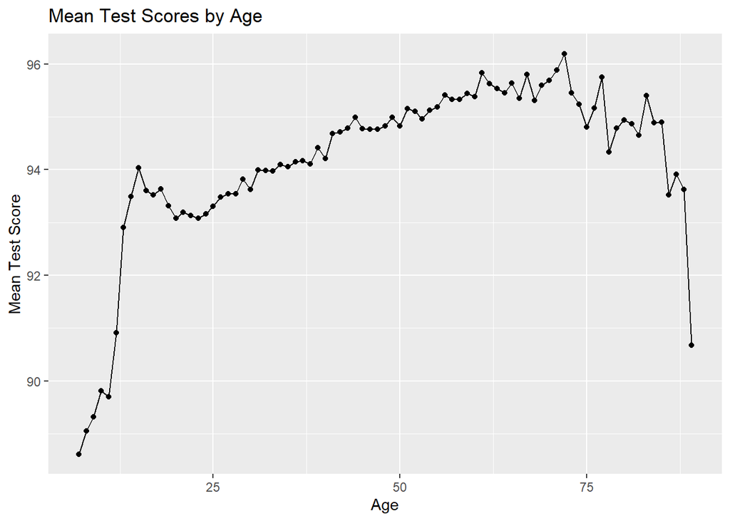

```r
mean_by_age <- df_eng_acquisition |>
  group_by(age) |>
  summarize(mean_score = mean(correct, NA.RM = TRUE))

ggplot(mean_by_age, aes(x=age, y=mean_score)) +
  geom_point() +
  geom_line() +
  labs(title="Mean Test Scores by Age",
       x="Age",
       y="Mean Test Score")
```

First, let’s filter out L1 English speakers. Second, let’s only consider respondents who have studied L2 English for AT LEAST two years. This is not an unreasonable number, but it should separate complete beginners from those who have had a substantial amount of time to learn.

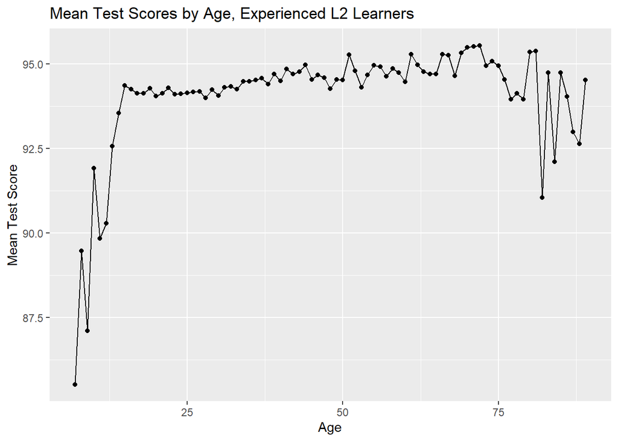

```r
mean_by_age_filtered <- df_eng_acquisition |>
  group_by(age) |>
  filter(L1_eng == 0 & eng_count >= 2) |>
  summarize(mean_score = mean(correct, NA.RM = TRUE))

ggplot(mean_by_age_filtered, aes(x=age, y=mean_score)) +
  geom_point() +
  geom_line() +
  labs(title="Mean Test Scores by Age, Experienced L2 Learners",
       x="Age",
       y="Mean Test Score")
```

It seems to be around adolescence when L2 learners start being highly proficient. The curve is very steady from then on! Could this suggest that there might be some sort of “second critical period” that ends in the late teens, as that is when the graph seems to level off?

The last thing I want to try is considering percentage of life spent studying English. My idea is that, if there is any “second critical period” whatsoever, that there should be a wide gulf in learning outcomes for older speakers who have spent a low percentage of their lives learning English as opposed to younger speakers for whom this is true. We’re going to indirectly plot density by coloring based on percentage of life spent learning English:

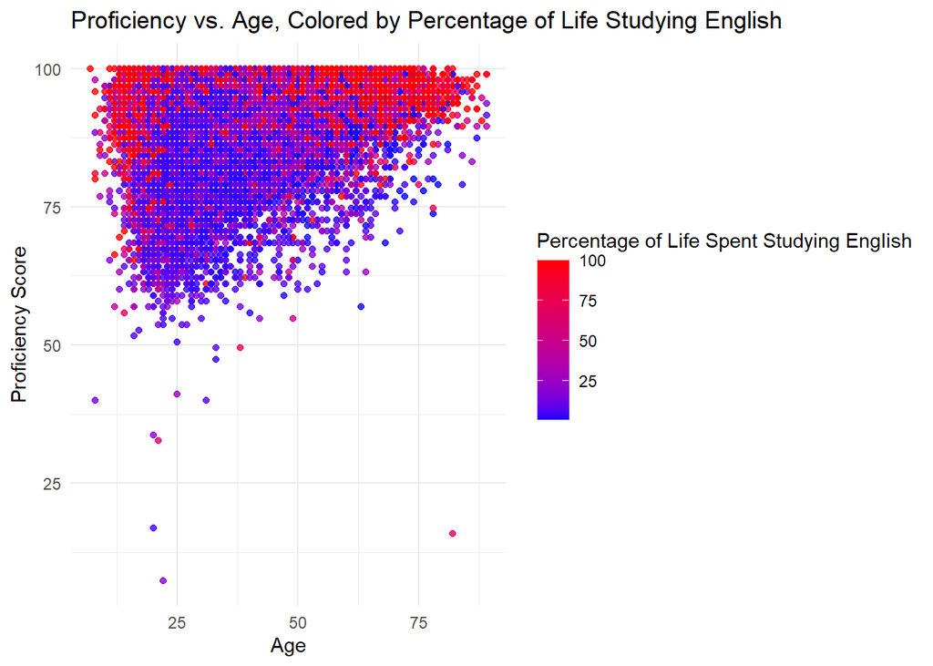

```r
df_eng_acquisition <- df_eng_acquisition |>
   mutate(percentage_life_spent = eng_count / age * 100) |>
   filter(L1_eng == 0 & eng_count >= 1) |>
   na.omit()


ggplot(df_eng_acquisition, aes(x = age, y = correct, color = percentage_life_spent)) +
  geom_point(alpha = 0.8) +  # Lower opacity to compensate for plot density
  scale_color_gradient(low = "blue", high = "red") +  # Gradient based on percentage_life_spent
  labs(title = "Proficiency vs. Age, Colored by Percentage of Life Studying English",
       x = "Age",
       y = "Proficiency Score",
       color = "Percentage of Life Spent Studying English") +
  theme_minimal()
```

## Exploring Question 2: Correlations between L1 and L2 English success

Let’s visualize correctness score by reported L1. We create a new dataframe by first separating rows with multiple reported L1s so their results can count for each language, and then selecting only the rows with a “0” for L1 English.

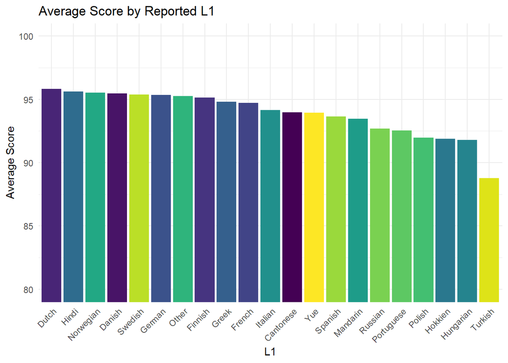

```r
df_acq_separated <- df_eng_acquisition |>
  separate_rows(L1s, sep = ",\\s*") |> #use comma as separator
  filter(L1_eng == 0)

#fix data for L1s reported as some variation of "Chinese/<Language>/<Language>" (for example, Chinese/Cantonese/Yue appears)
df_acq_separated <- df_acq_separated |>
  separate_rows(L1s, sep = "/") |> #don't need a regex whitespace check
  filter(L1s != "Chinese") #remove the columns that now just say "Chinese"

language_freqs <- df_acq_separated |>
  group_by(L1s) |>
  summarize(count = n()) |>
  filter(count >= 1500) #I found languages with 1500+ participants to be the sweet spot for graphing

language_scores <- df_acq_separated |>
  filter(L1s %in% language_freqs$L1s) |> #maybe there was a simpler way to do this, but it works and leaves the dataframe how I want it
  group_by(L1s) |>
  summarize(mean_pct = mean(correct, na.rm = TRUE))

language_scores |>
  filter(L1s != "NULL") |> #this is a string called "NULL", not the value, as imported from the csv data I guess
ggplot(aes(x = reorder(L1s, desc(mean_pct)), y = mean_pct, fill = L1s)) +
  geom_col(show.legend = FALSE) +
  coord_cartesian(ylim = c(80, 100)) + #start at 80 to emphasize discrepancies
  scale_fill_viridis_d(option = "D") +  #I love this gradient
  labs(title = "Average Score by Reported L1",
       x = "L1",
       y = "Average Score") +
  theme_minimal() +
  theme(axis.text.x = element_text(angle = 45, hjust = 1))  # preferable for readability
```

I really like this visualization. There are subtle confounding elements in the data, which give me pause in my judgments. For example, as expected, Germanic languages dominate the high end of correctness, and while this is certainly owed in part to shared parentage, I know that it is also much more common to learn English from an early age in Scandinavian countries and in places like Germany and the Netherlands.

For a similar reason, I am not sure what to make of Turkish being so low. Hindi being second overall does surprise me, as well! I wasn’t able to come up with a convincing theory as to why that would be, but I’m sure there is a sensible explanation. Overall, it would be hard to argue that no correlation exists here.

## 3. In-home English vs. Full Exposure

How much better is immersion in a language than just practicing it in the home? To find out, I’ll create a new column with existing data. We want to contrast participants who only spoke English in the home with those that lived in an English-speaking country and did not use English in the home. For the first category, let’s select participants with a 0 in home_eng and above 15% (arbitrarily set) for time spent in an English-speaking country. The second category would include those who have a 1 in home_eng and a 0 in lived_eng_pct.

```r
df_acq_home_immersion <- df_acq_separated |>
  mutate(home_or_immersion = case_when(home_eng == "0" & lived_eng_pct >= .15 ~ 2, #assign 2 for "immersion" case
  home_eng == "1" & lived_eng_pct == 0 ~ 1, #assign 1 for "home" case
                          TRUE ~ 0)) #assign 0 for everyone else
df_acq_home_only <- df_acq_home_immersion |>
  filter(home_or_immersion == 1)  #filter out "everyone else" cases
```

Actually, I tried to do this and found out that there are zero respondents who use English in the home but have never lived in an English-speaking country! Instead, then, let’s see if there are any values that seem to be breaking points for time spent in English-speaking countries. We can do this both by comparing percentages of time spent against correctness as well as comparing number of years against correctness using some math.

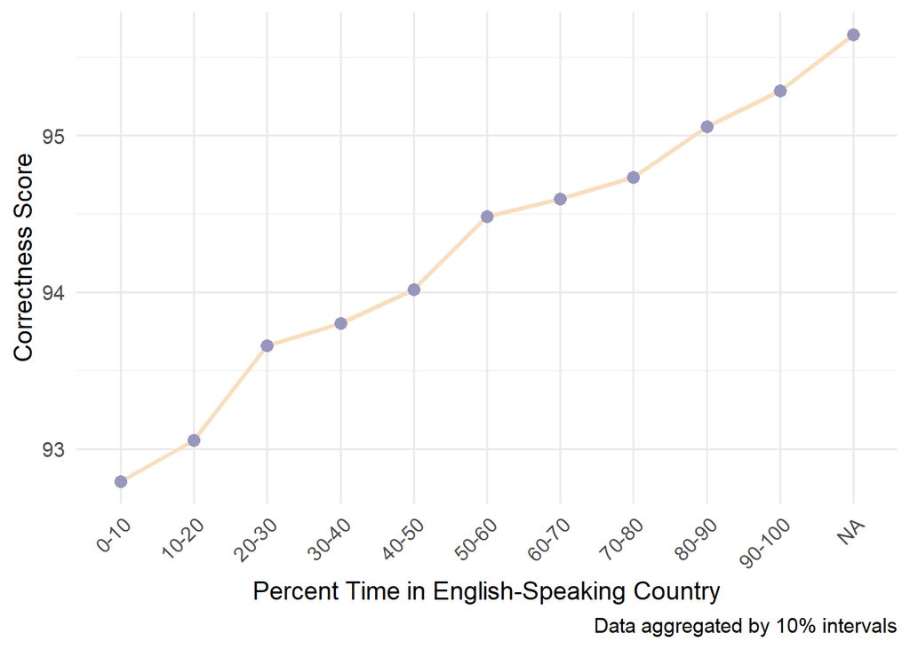

```r
df_acq_separated <- df_acq_separated |>
  mutate(lived_eng_pct = lived_eng_pct * 100) |>
  mutate(
    percentage_group = cut(lived_eng_pct, breaks = seq(0, 100, by = 10), include.lowest = TRUE, labels = paste(seq(0, 90, by = 10), seq(10, 100, by = 10), sep = "-")) #make labels 0-10, 10-20, etc
  )

grouped_scores <- df_acq_separated |>
  group_by(percentage_group) |>
  summarize(
    average_correct = mean(correct, na.rm = TRUE))

ggplot(grouped_scores, aes(x = percentage_group, y = average_correct, group = 1)) +
  geom_line(color = "#f9debd", size = 1.2) +
  geom_point(color = "#9797be", size = 3, shape = 21, fill = "#9797be") +  #I found out you can type these directly from color-hex.com!
  labs(
    x = "Percent Time in English-Speaking Country",
    y = "Correctness Score",
    caption = "Data aggregated by 10% intervals"
  ) +
  theme_minimal(base_size = 14) +
  theme(
    axis.text.x = element_text(angle = 45, hjust = 1, vjust = 1),
    #adjust x axis text spacing
    legend.position = "none"
  )
```

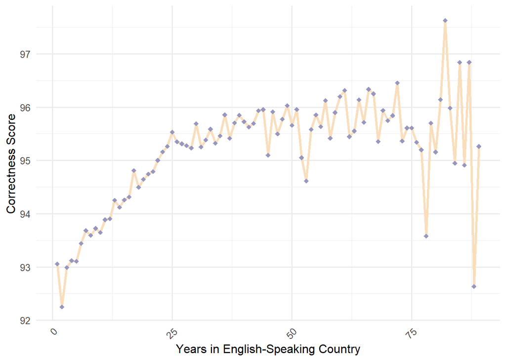

```r
df_acq_separated <- df_acq_separated |>
  mutate(years_eng = round((lived_eng_pct * age) / 100)) # divide by 100 since these are percentages, then round so grouping is possible

new_grouped_scores <- df_acq_separated |>
  group_by(years_eng) |>
  summarize(
    average_correct = mean(correct, na.rm = TRUE))

ggplot(new_grouped_scores, aes(x = years_eng, y = average_correct, group = 1)) +
  #messing around with manipulating sizes and choosing different shapes
  geom_line(color = "#f9debd", size = 1.2) +
  geom_point(color = "#9797be", size = 2, shape = 18, fill = "#9797be") +  #I wanted to use these colors again
  labs(
    x = "Years in English-Speaking Country",
    y = "Correctness Score"
  ) +
  theme_minimal(base_size = 12) +
  theme(
    axis.text.x = element_text(angle = 45, hjust = 1, vjust = 1),
    legend.position = "none"
  )
```

This relationship seems to largely be linear until 25 years or so, where it really levels off. It could just be that there are way fewer respondents who’ve lived 25+ years in an English-speaking country, but there is probably some truth to that leveling off.

I would have expected it this to happen many years prior, though. This seems to imply that L2 English learning could continue fairly steadily even 20 years into one’s residency in an English-speaking country, which would be a great result!

## 4. Dyslexia and Psychiatric Disorders

I don’t want to go overboard with this, nor try to make any judgments about correlation or causation. But still, since the data was collected, it would be nice to see if anything stands out visually. It makes logical sense that dyslexia could interfere with language learning, but I have no idea how much impact it might have.

Well… this was my plan, but then I found out that not a single row has “1” in the dyslexia column. I checked the CSV file and, sure enough, there wasn’t a single 1. Disappointing! I don’t know what happened to the data there. I will have to just compare 1 in psychiatric to 0 in psychiatric.

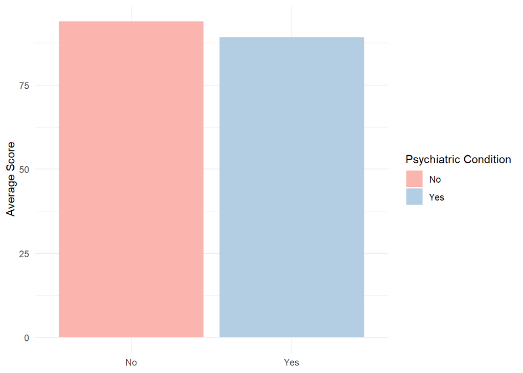

```r
#here is what the code might have looked like
#df_acq_separated <- df_acq_separated |>
 # mutate(none_dys_psych = case_when(dyslexia == 0 & psychiatric == 0 ~ "neither", #neither dyslexia nor psychiatric disorders reported
 # dyslexia == 1 & psychiatric == 0 ~ "dyslexia", #only dyslexia reported
 # dyslexia == 0 & psychiatric == 1 ~ "psychiatric"))

correct_psychiatric <- df_acq_separated |>
  group_by(psychiatric) |>
  summarize(score = mean(correct, na.rm = TRUE))

correct_psychiatric$psychiatric <- correct_psychiatric$psychiatric |>
  factor(levels = c(0, 1), labels = c("No", "Yes")) #change to no and yes for clarity when graphing

ggplot(correct_psychiatric, aes(x = as.factor(psychiatric), y = score, fill = as.factor(psychiatric))) +
  geom_col() +
  scale_fill_brewer(palette = "Pastel1", name = "Psychiatric Condition") + #switching up the colors again
  labs(
       x = NULL,
       y = "Average Score") +
  theme_minimal()
```

```r
    # Improving readability of the x-axis labels
```

## 5. Final Topic: Comparing English-Speaking Countries

This one is pretty simple. I want to separate the “countries” column into multiple rows for each country. For all L2 English learners who have lived in one of the English-speaking countries included in the study (the UK, the US, Ireland, and Canada), I will investigate if any sizable difference in average score exists.

```r
df_acq_eng_countries <- df_eng_acquisition |>
  separate_rows(countries, sep = ",\\s*") |>
  filter(L1_eng == 0)
```

I do think that in the first place, it’s important to see if the sample size for a country like Ireland is significant enough to plot. This is easy enough to inline in markdown text.

For the four English-speaking countries, the results are 40337 respondents from the US, 33992 respondents from the UK, 12153 respondents from Canada, and 4647 respondents from Ireland.

Even though the number of Ireland residents is predictably low, I think around 5000 is plenty to establish a trend. Let’s compare scores!

```r
eng_countries_scores <- df_acq_eng_countries |>
  filter(countries %in% c("United States", "United Kingdom", "Canada", "Ireland (Republic of)")) |>
  group_by(countries) |>
  summarize(score = mean(correct, na.rm = TRUE)) |>
  arrange(score)

eng_countries_scores$countries[1] <- "Ireland" #so it doesn't say Ireland (Republic of) when I inline results
```

The results are as follows: Ireland is in last place, with a mean score of 94. United Kingdom is in third, with a score of 94.5. United States comes in second, with an average of 94.7, leaving, as the winner: Canada, with the best score, at…huh. 94.9 percent.

As it turns out, these four English-speaking countries seem to all do an equally great job fostering L2 English acquisition. The total deviation amount from lowest score to highest is less than 1 percent! This is good news. Well done, Canada!

Even though Ireland seems to have a larger gap between it and the other countries, the sample size was by far the lowest. This could also explain Canada’s outcome being the best. The US beat the UK, and that is a good enough result for me!

## Conclusion

It was definitely fun to look for correlations and try my best to interpret some of the data. It is unfortunate that there were some instances (particularly with dyslexia) where something weird must have happened to the original .csv file.

One issue with this dataset is that there’s not much context for what the assessment actually consisted of. I read what I could find about this study (there is a short paper), but it did not provide much clarity. We therefore have no real indication of grammaticality might have been judged. This is something that is not well-addressed in the provided data, and so it is possible that the methods used could have been controversial or unrepresentative in some way.

Still, getting to make my own visualizations for the data is exciting in that I might be able to represent patterns in a way that the original study did not think to try (though I am not convinced that I succeeded in that here). The goal of this project is representing both my continued growth with data visualization and analysis in R and my reporting skills, and I hope I succeeded on those fronts.

Finally, I’d like to thank you for this class - it was a great introduction to R, and I have confidence that I would be able to apply this to linguistics problems now!